# Plot complex tree of ORs in inquilines

[output not shown]

```
Lade n<c3><b6>tiges Paket: maps
```

`r`r library(phytools) library(geiger) library(cowplot)

`r`r ############################################ # Load rerooted FastTree tree ############################################ t1<-read.tree(/Users/lukas/sciebo/inquilineGenomics18/ORevolution/results/tree/ant.OR.rooted.tre) #tree <- as(t1, ‘TreeMan’)

`r`r ############################################ # Load subfam assignments ############################################ subfam<-read.table(/Users/lukas/sciebo/inquilineGenomics18/ORevolution/results/tree/ORsubfamily.assignment.tsv,sep=\t)

`r`r classSubfam<-as.character(subfam$V2) names(classSubfam)<-subfam$V1

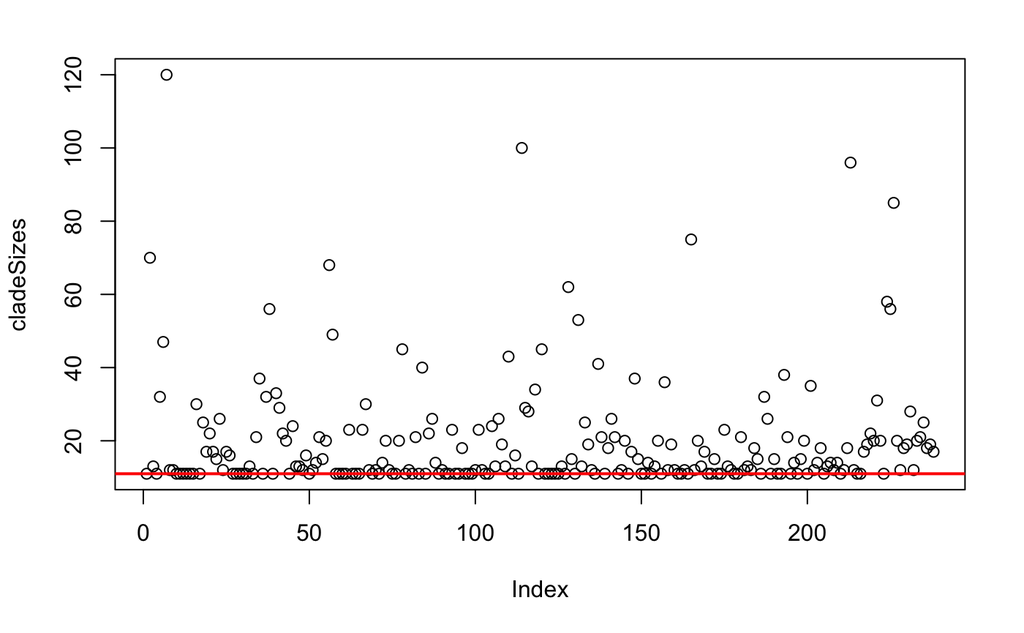

`r`r

# par(mai=c(2,2,2,2))

# trait.plot(t1,traitsAll ,list(traits = c(70, rgb(1,0,0,1)),traits5 = c(80, rgb(1,.1,0,1)),traits4 = c(90, rgb(1,.1,.1,1))),cex.lab = .0001,w=.2,margin=1)

`r`r # ggtree library(RColorBrewer) source(~/sciebo/librarySchrader.R)

`r`r plotSF<-subfam$V2 names(plotSF)<-subfam$V1 t1000<-merge(data.frame(plotSF),data.frame(traits3),by=.names) row.names(t1000)<-t1000$Row.names t1000<-t1000[,2:3] t1000$traits3<-as.factor(t1000$traits3)

tree_plot3 <- gheatmap(tree_plot2,t1000[,3, drop=F] , offset = 1, width=.1, font.size=.1, colnames_angle=-45, hjust=0,color=NA)

col <- c(rep(c(80,70),13),80, brewer.pal(4, 1)[1:2]) names(col) = c(letters[1:27], letters[1:2]) pp <- tree_plot3 + scale_fill_manual(values=col)

# names(col) = c(letters[1:29])

# https://bioconductor.statistik.tu-dortmund.de/packages/3.5/bioc/vignettes/ggtree/inst/doc/advanceTreeAnnotation.html

# https://groups.google.com/forum/#!topic/bioc-ggtree/WkxI0r7x098

`r`r p1x <- p1 + scale_fill_manual(values=col)

`r`r p2x <- gheatmap(circ, df[, , drop=F], offset=5, width=.1) + scale_fill_manual(values=col)

[figure not shown]

`r`r p1 <- gheatmap(t1, t1000[,, drop=F], offset=.8, width=.1, colnames_angle=90, colnames_offset_y = .25)

[output not shown]